# Hwk #2: Classification methods and Penalization

For this homework we will use NHANES data that exists in a package for R.

NHANES consists of survey data collected by the US National Center for Health Statistics (NCHS) which has conducted a series of health and nutrition surveys since the early 1960’s. Since 1999 approximately 5,000 individuals of all ages are interviewed in their homes every year and complete the health examination component of the survey. The health examination is conducted in a mobile examination center (MEC).

Note that there is the following warning on the NHANES website: “For NHANES datasets, the use of sampling weights and sample design variables is recommended for all analyses because the sample design is a clustered design and incorporates differential probabilities of selection. If you fail to account for the sampling parameters, you may obtain biased estimates and overstate significance levels.”

For this homework, please ignore this warning and just apply our analyses to the data as if they were randomly sampled! We will be using the data called `NHANESraw`.

For questions that ask for your comments, it suffices to answer with one or two sentences in each case.

## Data Preparation

1. Install the package `NHANES` into R, load the `NHANES` package, and then run the command `data(NHANES)` which will load the NHANES data. Type `?NHANES` and read about the dataset.

```r
# Code is commented out for knitting.
# install.packages("NHANES")

library("NHANES")
data(NHANES)

# ?NHANES
```

2. Make an object `nhanes` that is a subset version `NHANESraw` that does not include any missing data for `Diabetes`, `BPSysAve`, `BPDiaAve`, or `Age`.

```r
nhanes <- copy(NHANESraw)
setDT(nhanes)

nhanes <- nhanes[!is.na(Diabetes),]
nhanes <- nhanes[!is.na(BPSysAve),]
nhanes <- nhanes[!is.na(BPDiaAve),]
nhanes <- nhanes[!is.na(Age),]
```

3. (1 point) Further subset the data such the observations with `BPDiaAve` equal to zero are removed.

```r
nhanes <- nhanes[!BPDiaAve == 0]
```

4. (1 point) Make an object `nhanes09` that is a subset of `nhanes` to only the 2009_10 data. This will be your training dataset. Also make an object `nhanes11` that is a subset of `nhanes` to only the 2011_12 data. This will be your test dataset.

```r
nhanes09 <- nhanes[SurveyYr == "2009_10"]
nhanes09$SurveyYr <- droplevels(nhanes09$SurveyYr)

nhanes11 <- nhanes[SurveyYr == "2011_12"]
nhanes11$SurveyYr <- droplevels(nhanes11$SurveyYr)
```

## Logistic regression

5. (2 point) Fit a logistic regression model (call it `glm1`) using the `nhanes09` dataset. Use `Diabetes` as the outcome and averaged systolic blood pressure (`BPSysAve`) as a single predictor. Use the summary command to examine the fitted model. Generate the 95% confidence intervals for the `BPSysAve` coefficient.

```r
glm1 <- glm(Diabetes ~ BPSysAve, data = nhanes09, family = "binomial")
summary(glm1)
```

```
##
## Call:
## glm(formula = Diabetes ~ BPSysAve, family = "binomial", data = nhanes09)
##
## Deviance Residuals:
##     Min       1Q   Median       3Q      Max
## -1.5554  -0.4892  -0.4149  -0.3510   2.5957
##
## Coefficients:
##              Estimate Std. Error z value Pr(>|z|)
## (Intercept) -5.645247   0.224502  -25.15   <2e-16 ***
## BPSysAve     0.028892   0.001761   16.41   <2e-16 ***
## ---
## Signif. codes:  0 '***' 0.001 '**' 0.01 '*' 0.05 '.' 0.1 ' ' 1
##
## (Dispersion parameter for binomial family taken to be 1)
##
##     Null deviance: 5245.1  on 7724  degrees of freedom
## Residual deviance: 4983.9  on 7723  degrees of freedom
## AIC: 4987.9
##
## Number of Fisher Scoring iterations: 5
```

```r
confint(glm1)
```

```
##                   2.5 %      97.5 %
## (Intercept) -6.08759789 -5.20726141
## BPSysAve     0.02544521  0.03235066
```

6. (1 point) Generate the estimate and 95% confidence interval for the odds-ratio associated with BPSysAve. Summarize the result.

```r
# odds ratio
exp(coefficients(glm1))
```

```
## (Intercept)    BPSysAve
## 0.003534275 1.029313254
```

```r
# confidence interval for the odds ratio
exp(confint(glm1))
```

```
##                   2.5 %      97.5 %
## (Intercept) 0.002270857 0.005476651
## BPSysAve    1.025771698 1.032879636
```

For every 1 mmHg increase in a participant’s average systolic blood pressure, s/he has 1.03 (95% CI, 1.026 - 1.033) times the odds of having diabetes. In other words, for every 1 mmHg increase in a participant’s average systolic blood pressure, s/he has a 3% higher odds of having diabetes.

7. (1 point) Predict the probabilities of diabetes associated with each of the training observations of `BPSysAve`. Make a vector of predictions for diabetes based on whether the predictions are above or below 0.5.

```r
# predict the probabilities
predictions <- predict(glm1, type = "response")

# vector of predictions
# 0 is no diabetes if the predicted probability is <=0.5
# 1 is yes diabetes if the predicted probability is >0.5
diabetes_pred <- ifelse(predictions <= 0.5, 0, 1)

# make this a factor equivalent to the nhanes09 dataset
diabetes_pred <- factor(diabetes_pred, labels = c("No", "Yes"))
```

8. (1 point) Generate a confusion matrix that shows the number of false positives, false negatives, true positives, and true negatives in the training data. The rows should correspond to the true diabetes status and the columns should correspond to the predicted values.

```r
table(true_status = nhanes09$Diabetes, predictions = diabetes_pred)
```

```
##            predictions
## true_status   No  Yes
##         No  6885   16
##         Yes  817    7
```

9. (1 point) Find the proportion of correctly classified observations in the training data.

```r
mean(nhanes09$Diabetes == diabetes_pred)
```

```
## [1] 0.8921683
```

10. (2 points) Now repeat questions 7 to 9 but for predicting the test dataset.

```r
# predict the probabilities
predictions_test <- predict(glm1, newdata = nhanes11, type = "response")

# vector of predictions
# 0 is no diabetes if the predicted probability is <=0.5
# 1 is yes diabetes if the predicted probability is >0.5
diabetes_pred_test1 <- ifelse(predictions_test <= 0.5, 0, 1)

# make this a factor equivalent to the nhanes11 dataset
diabetes_pred_test1 <- factor(diabetes_pred_test1, labels = c("No", "Yes"))

# confusion matrix
table(true_status = nhanes11$Diabetes, predictions = diabetes_pred_test1)
```

```
##            predictions
## true_status   No  Yes
##         No  6195   13
##         Yes  757    4
```

```r
# accuracy
mean(nhanes11$Diabetes == diabetes_pred_test1)
```

```
## [1] 0.8895107
```

11. (1 point) Comment on the difference in results between the training and test prediction tables and classification accuracies.

```r
mean(nhanes11$Diabetes == "No")
```

```
## [1] 0.8908021
```

There is little difference in the prediction tables and classification accuracies between the training and test datasets. Importantly, the seemingly high accuracy in prediction is driven by model predicting “No” diabetes for nearly all observations. Because there are many more “No”s than “Yes”es, this inflates the accuracy significantly. A model that only predicted “No” for all observations would have an accuracy of 89.1%, better than the model’s accuracy on the testing data!

12. (1 point) Manually calculate the sensitivity and specificity estimates for the test dataset based on the 0.5 threshold.

```r
# sensitivity
4/(4+757)
```

```
## [1] 0.005256242
```

```r
# specificity
6195/(6195+13)
```

```
## [1] 0.9979059
```

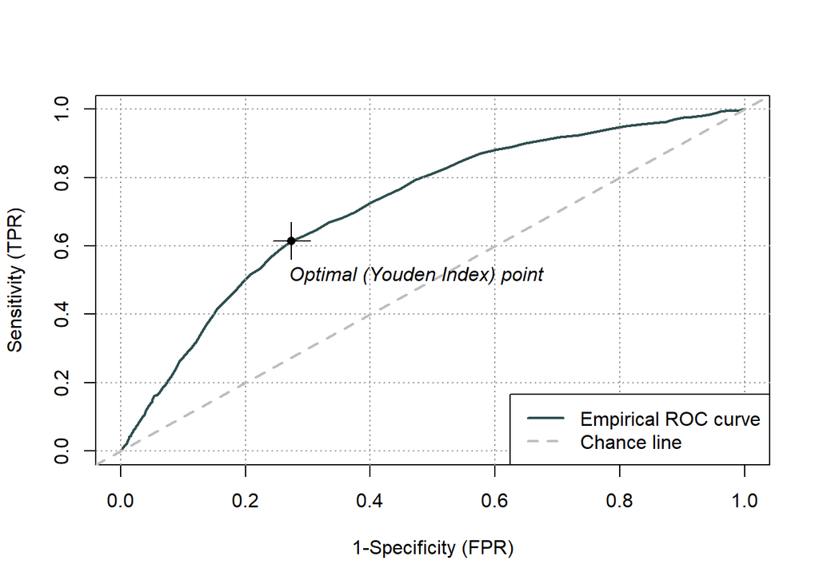

```r
rocit_obj <- rocit(score = predictions_test, class = nhanes11$Diabetes)
plot(rocit_obj)
```

14. What value can you use to threshold the predicted probability to achieve a sensitivity of at least 0.6 and a specificity of at least 0.3?

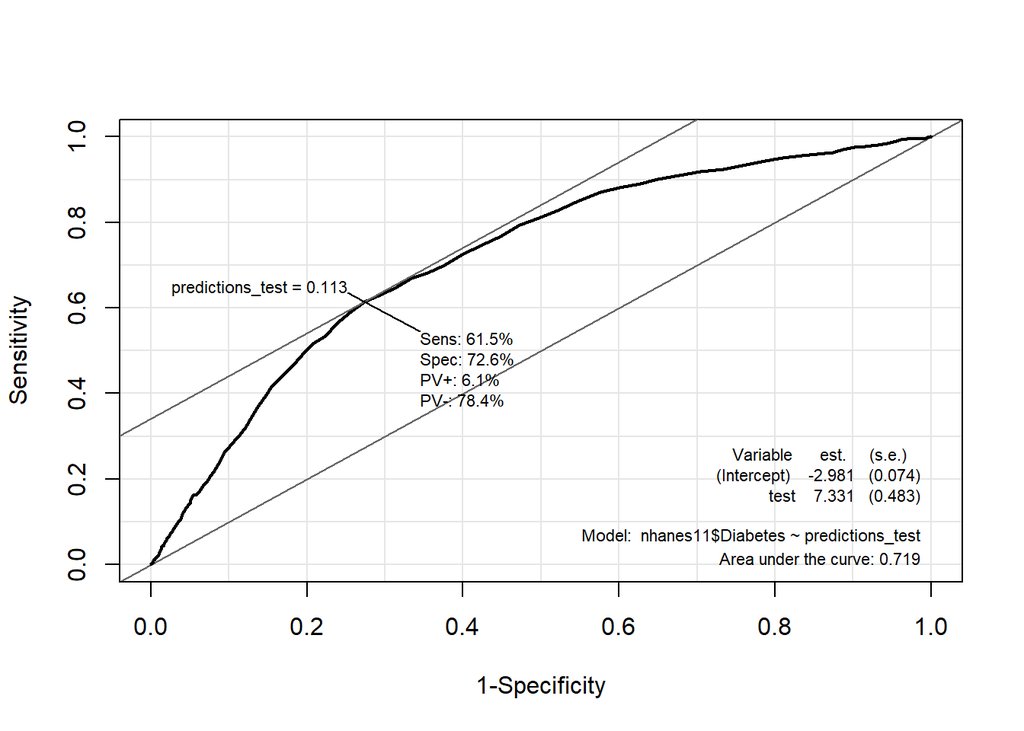

```r
ROC(test = predictions_test, stat = nhanes11$Diabetes, plot = "ROC")
```

By using the `ROC()` function in the `Epi` package, an optimal threshold of the predicted probability is identified on the ROC curve plot. Setting the predicted probability threshold to ~0.113 will give the model a sensitivity of 61.5% and a specificity of 72.6%.

15. (2 points) Comment on the results of the analyses for the different thresholds in terms of the tables, classification accuracies, and sensitivity and specificity. Under what circumstances might you prefer each of the thresholds?

```r
# setting the threshold based on the optimal point in the above curve
diabetes_pred_test2 <- ifelse(predictions_test <= 0.113, 0, 1)

# make this a factor equivalent to the nhanes11 dataset
diabetes_pred_test2 <- factor(diabetes_pred_test2, labels = c("No", "Yes"))

# confusion matrix
table(true_status = nhanes11$Diabetes, predictions = diabetes_pred_test2)
```

```
##            predictions
## true_status   No  Yes
##         No  4509 1699
##         Yes  293  468
```

```r
# data table of threshold 0.5 vs threshold 0.11
data.table(
    threshold = c("0.5", "0.113"),
    accuracy = c(mean(nhanes11$Diabetes == diabetes_pred_test1),
                 mean(nhanes11$Diabetes == diabetes_pred_test2)),
    sensitivity = c(4/(4+757), 468/(468+293)),
    specificity = c(6195/(6195+13), 4509/(1699+4509))
)
```

```
##    threshold  accuracy sensitivity specificity
## 1:       0.5 0.8895107 0.005256242   0.9979059
## 2:     0.113 0.7141627 0.614980289   0.7263209
```

Setting the threshold probability at 0.5 generates predictions that are excellent at reducing false positives (i.e., patients are most likely to be labeled as “No diabetes”). This would be an ideal threshold if diagnosing someone with diabetes would trigger invasive testing, but missing cases of diabetes would not be harmful. As illustrated above, a threshold of 0.5 is akin to predicting that all participants did **not** have diabetes.

16. (2 points) Fit a multiple predictor logistic regression (call it `glm2`) with `Diabetes` as outcome and predictors: `BPSysAve`, `BPDiaAve`, and `Age`. Use the `summary` command to examine the fitted model and determine the estimated coefficients, odds-ratios, and 95% confidence intervals thereof.

```r
# fit the model
glm2 <- glm(Diabetes ~ BPSysAve + BPDiaAve + Age, data = nhanes09, family = "binomial")

# show the model summary
summary(glm2)
```

```
##
## Call:
## glm(formula = Diabetes ~ BPSysAve + BPDiaAve + Age, family = "binomial",
##     data = nhanes09)
##
## Deviance Residuals:
##     Min       1Q   Median       3Q      Max
## -1.1027  -0.4916  -0.2862  -0.1874   2.9814
##
## Coefficients:
##              Estimate Std. Error z value Pr(>|z|)
## (Intercept) -5.076129   0.283412 -17.911   <2e-16 ***
## BPSysAve     0.004657   0.002281   2.042   0.0412 *
## BPDiaAve    -0.002999   0.003181  -0.943   0.3458
## Age          0.051655   0.002423  21.318   <2e-16 ***
## ---
## Signif. codes:  0 '***' 0.001 '**' 0.01 '*' 0.05 '.' 0.1 ' ' 1
##
## (Dispersion parameter for binomial family taken to be 1)
##
##     Null deviance: 5245.1  on 7724  degrees of freedom
## Residual deviance: 4401.8  on 7721  degrees of freedom
## AIC: 4409.8
##
## Number of Fisher Scoring iterations: 6
```

```r
# list the estimated coefficients
coefficients(glm2)
```

```
##  (Intercept)     BPSysAve     BPDiaAve          Age
## -5.076128788  0.004656572 -0.002999295  0.051655493
```

```r
# list the odds ratios
exp(coefficients(glm2))
```

```
## (Intercept)    BPSysAve    BPDiaAve         Age
## 0.006244034 1.004667430 0.997005198 1.053012909
```

```r
# list the 95% confidence intervals of the odds ratios
exp(confint(glm2))
```

```
##                   2.5 %     97.5 %
## (Intercept) 0.003571939 0.01085308
## BPSysAve    1.000171029 1.00915651
## BPDiaAve    0.990833227 1.00327024
## Age         1.048083446 1.05808956
```

17. (2 points) Generate an ROC curve for the `glm2` model using the test data. What is the AUC and its 95% confidence interval?

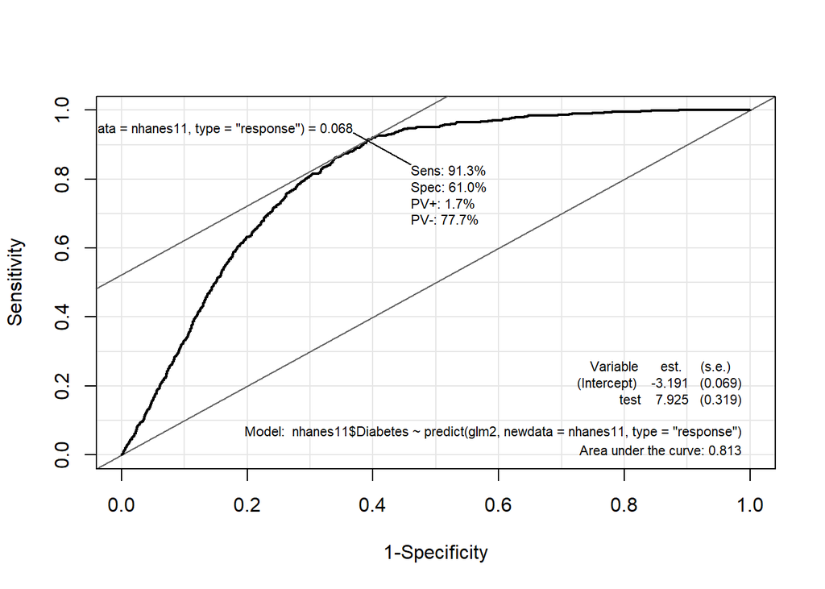

```r
rocit_obj2 <- rocit(score = predict(glm2, newdata = nhanes11, type = "response"),
                    class = nhanes11$Diabetes)
ROC(test = predict(glm2, newdata = nhanes11, type = "response"),
    stat = nhanes11$Diabetes, plot = "ROC")
```

```r
ciAUC(rocit_obj2)
```

```
##
##    estimated AUC : 0.812555352256255
##    AUC estimation method : empirical
##
##    CI of AUC
##    confidence level = 95%
##    lower = 0.793592417743851     upper = 0.831518286768659
```

18. (1 point) What is the maximum sensitivity level you can achieve if we require the specificity to be at least 0.3?

```r
table_sens.spec <- measureit(rocit_obj2, measure = c("SPEC", "SENS"))
setDT(table_sens.spec)
tail(table_sens.spec[SPEC >=0.3], 1)
```

```
##        Cutoff     Depth  TP   FP   TN FN      SENS      SPEC
## 1: 0.02305682 0.7312383 751 4345 1863 10 0.9868594 0.3000966
```

The maximum sensitivity level that can be achieved if the specificity is required to be at least 0.3 is about 0.987 with a threshold of 0.023.

## Linear discriminant analysis

20. (2 points) Fit a linear discriminant analysis (`lda1`) with `Diabetes` as outcome and predictors of `BPSysAve`, `BPDiaAve`, and `Age` in the training dataset. Examine the fit by typing `lda1`.

```r
lda1 <- lda(Diabetes ~ BPSysAve + BPDiaAve + Age, data = nhanes09)
lda1
```

```
## Call:
## lda(Diabetes ~ BPSysAve + BPDiaAve + Age, data = nhanes09)
##
## Prior probabilities of groups:
##        No       Yes
## 0.8933333 0.1066667
##
## Group means:
##     BPSysAve BPDiaAve      Age
## No  116.5382 65.68106 37.78844
## Yes 128.3180 66.86529 60.83374
##
## Coefficients of linear discriminants:
##                  LD1
## BPSysAve  0.01042485
## BPDiaAve -0.01806242
## Age       0.04469600
```

21. (2 points) Generate the confusion matrix for `lda1` using the test set. Compute the classification accuracy, sensitivity, and specificity.

```r
# generate predictions
lda_predictions <- predict(lda1, newdata = nhanes11)

# create confusion matrix
table(true_status = nhanes11$Diabetes, predictions = lda_predictions$class)
```

```
##            predictions
## true_status   No  Yes
##         No  6158   50
##         Yes  738   23
```

```r
# accuracy
mean(nhanes11$Diabetes == lda_predictions$class)
```

```
## [1] 0.8869278
```

```r
# sensitivity
23/(23+738)
```

```
## [1] 0.03022339
```

```r
# specificity
6158/(6158+50)
```

```
## [1] 0.9919459
```

22. How do these measures compare with that of the logistic regression model with these predictors and 0.5 threshold?

```r
# set threshold at 0.5 and predict on logistic regression model
pred_thresh_0.5 <- ifelse(predict(glm2, newdata = nhanes11, type = "response") <= 0.5, 0, 1)
diabetes_multi.log <- factor(pred_thresh_0.5, levels = c(0,1), labels = c("No", "Yes"))

data.table(
    model = c("logistic", "LDA"),
    accuracy = c(mean(nhanes11$Diabetes == diabetes_multi.log),
                 mean(nhanes11$Diabetes == lda_predictions$class)),
    sensitivity = c(0/761, 23/(23+738)),
    specificity = c(6208/6208, 6158/(6158+50))
)
```

```
##       model  accuracy sensitivity specificity
## 1: logistic 0.8908021  0.00000000   1.0000000
## 2:      LDA 0.8869278  0.03022339   0.9919459
```

The logistic regression model has a slightly higher accuracy, but both models are nearly useless practically as has been discussed in several other questions here. The specificity of both models is high, sacrificing sensitivity and either (1) predicting very few people to have diabetes in the case of the LDA model or (2) predicting **no one** to have diabetes in the case of the multivariate logistic regression model. The accuracy of both models is high because a majority of participants do not have diabetes in the dataset and by only predicting “No” diabetes, the accuracy is equivalent to the proportion of patients without diabetes.

23. (3 points) Redo question 21 but with prior probabilities set to 0.5 for diabetes.

```r
# generate predictions with prior probabilities set to 0.5
lda_predictions.prior <- predict(lda1, newdata = nhanes11,
                                 prior = c(No = 0.5, Yes = 0.5))

# create confusion matrix
table(true_status = nhanes11$Diabetes, predictions = lda_predictions.prior$class)
```

```
##            predictions
## true_status   No  Yes
##         No  4630 1578
##         Yes  196  565
```

```r
# accuracy
mean(nhanes11$Diabetes == lda_predictions.prior$class)
```

```
## [1] 0.7454441
```

```r
# sensitivity
565/(565+196)
```

```
## [1] 0.7424442
```

```r
# specificity
4630/(4630+1578)
```

```
## [1] 0.7458119
```

24. (2 points) Comment on how LDA’s performance changed when we changed the prior probabilities.

```r
data.table(
    prior.prob = c("default", "50-50"),
    accuracy = c(mean(nhanes11$Diabetes == lda_predictions$class),
                 mean(nhanes11$Diabetes == lda_predictions.prior$class)),
    sensitivity = c(23/(23+738), 565/(565+196)),
    specificity = c(6158/(6158+50), 4630/(4630+1578))
)
```

```
##    prior.prob  accuracy sensitivity specificity
## 1:    default 0.8869278  0.03022339   0.9919459
## 2:      50-50 0.7454441  0.74244415   0.7458119
```

## Penalized regression

26. Read in the dementia data “dementia2.csv” into a data frame called `dementia_dat`. This dataset contains measurements obtained from MRI brain scans and whether or not the patient has dementia. We’ll try to build a prediction model for diagnosing dementia based on these derived measurements. How many observations are in this dataset? How many predictors are in this dataset?

```r
# read in the data
dementia_dat <- fread("dementia2.csv")

# how many observations?
nrow(dementia_dat)
```

```
## [1] 660
```

```r
# how many predictors?
ncol(dementia_dat)
```

```
## [1] 143
```

27. Load the `glmnet` and `caret` packages.

```r
library(glmnet)
library(caret)
```

28. (1 point) Set the random seed to 4 and then split the data into 2 sets (400 train, and 260 test)

```r
# set the seed
set.seed(4)

# get the sampling index
dementia_dat$Dementia <- factor(dementia_dat$Dementia)
samplerIndex <- createDataPartition(dementia_dat$Dementia, times = 1, p = 399/660,
                                    list = FALSE)

# training set
train_dementia <- dementia_dat[samplerIndex,]
nrow(train_dementia)
```

```
## [1] 400
```

```r
# test set
test_dementia <- dementia_dat[-samplerIndex,]
nrow(test_dementia)
```

```
## [1] 260
```

29. (4 points) Perform cross-validated lasso in the training data to select the optimal penalty parameter lambda. Use 5 folds and search over the range $\lambda = 10^{3}$ to $\lambda = 10^{-3}$. Set `Dementia` as outcome with all other variables as predictors except `MacCohort_kr`. Use the `caret` package to do CV.

```r
# do 5-fold cross-validation
fitControl <- trainControl(method = "cv", number = 5)

# set the range of lambdas to tune across
lambda.range <- 10^seq(from = -3, to = 3, by = 0.05)

# create a matrix of tuning parameters
tune.matrix <- data.frame(lambda = lambda.range, alpha = 1)

# train the model using cross-validation
cv.model <- train(Dementia ~ . - MacCohort_kr,
                  data = train_dementia,
                  trControl = fitControl,
                  method = "glmnet",
                  tuneGrid = tune.matrix)
```

30. (1 point) What is the optimal value of lambda?

```r
cv.model$bestTune
```

```
##    alpha      lambda
## 20     1 0.008912509
```

31. (1 point) Generate the confusion matrix for this final model.

```r
# get the test data ready for the predict() function
test_matrix <- model.matrix(Dementia~.-MacCohort_kr, data = test_dementia)[,-1]

# generate the predictions
cv.predictions <- predict(cv.model$finalModel, s = cv.model$bestTune[,2],
                          newx = test_matrix, type = "class")

# generate the confusion matrix
table(true_status = test_dementia$Dementia, predictions = cv.predictions)
```

```
##            predictions
## true_status  No Yes
##         No  116   8
##         Yes  23 113
```

32. (1 point) How many non-zero coefficients are in the final model?

```r
sum( abs(coef(cv.model$finalModel, s = cv.model$bestTune[,2])) > 0 )
```

```
## [1] 36
```